# Eindopdracht Daur2_V7

Ghislaine van Gilse & Omar Sprockel

03-11-2022

Opdracht 1

Korte introductie Hersenonderzoek naar een ziekte is erg lastig. Het is niet mogelijk om hersencellen te isoleren uit levende patiënten. Hier is een alternatief voor bedacht. Er worden fibroblasten uit de patiënt geïsoleerd en deze worden terug gedifferentieerd naar geïnduceerde pluripotente stamcellen en deze worden vervolgens omgezet naar hersencellen. Dit kost echter relatief veel tijd. Een alternatief is de fibroblasten direct omzetten naar de hersencellen, dit heet transdifferentiatie. Om een beter beeld te krijgen van de cellen van een patiënt, worden de cellen vergeleken met cellen van een gezond individu. In dit onderzoek zijn de fibroblasten afkomstig van één proefpersoon. Hierbij wordt een deel van de cellen behandeld met een controle transcriptiefactor (BCLXL) en een ander deel van de cellen met een transcriptiefactor (ONECUT1). Er wordt verwacht dat onder invloed van ONECUT1 de cellen kunnen differentiëren tot hersencellen. Vervolgens gaat er gekeken worden naar de verschillen in genexpressie tussen de BCLXL behandelde cellen en de met de ONECUT1 behandelde cellen.

Opdracht 2

```
## [1] "Over het algemeen ziet de kwaliteit van de fastq bestanden er goed genoeg uit. Zowel de per base sequence quality als de per sequence quality scores zien er goed uit. Afbeelding 1 & 2 geven de slechtste file weer, de rest van de files lijkt meer zoals afbeelding 3."
```

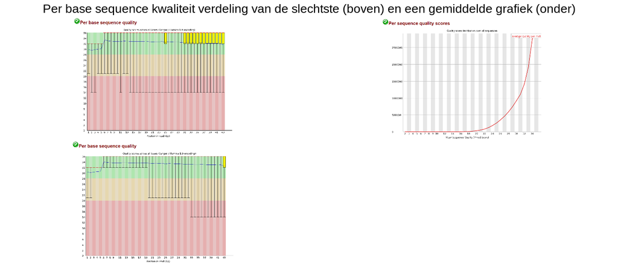

Opdracht 3

```r
# Create object with input dir for bam files
bam_dir <- "/home/daur2/rnaseq/rnaseq_onecut/bam/"

# Create object with output dir for count tables
counts_dir <- "/home/daur2/rnaseq/rnaseq_onecut/counts/"

# Create vector with names of bam files
bam_files <- list.files(bam_dir, pattern = "SRR7866699.bam”, “SRR7866700.bam”, “SRR7866701.bam”, “SRR7866702.bam", full.names = TRUE)

# Count the reads per gene using the in-built NCBI RefSeq annotations
read_counts <- featureCounts(files = bam_files,
                             annot.inbuilt = "hg38",
                             useMetaFeatures = TRUE,
                             strandSpecific = 1,
                             isPairedEnd = TRUE,
                             countReadPairs = TRUE,
                             nthreads = 10)
```

Opdracht 5a

```
##                             PC1      PC2      PC3         PC4
## Standard deviation     38.44093 9.561226 7.233422 1.04819e-13
## Proportion of Variance  0.91135 0.056380 0.032270 0.00000e+00
## Cumulative Proportion   0.91135 0.967730 1.000000 1.00000e+00
```

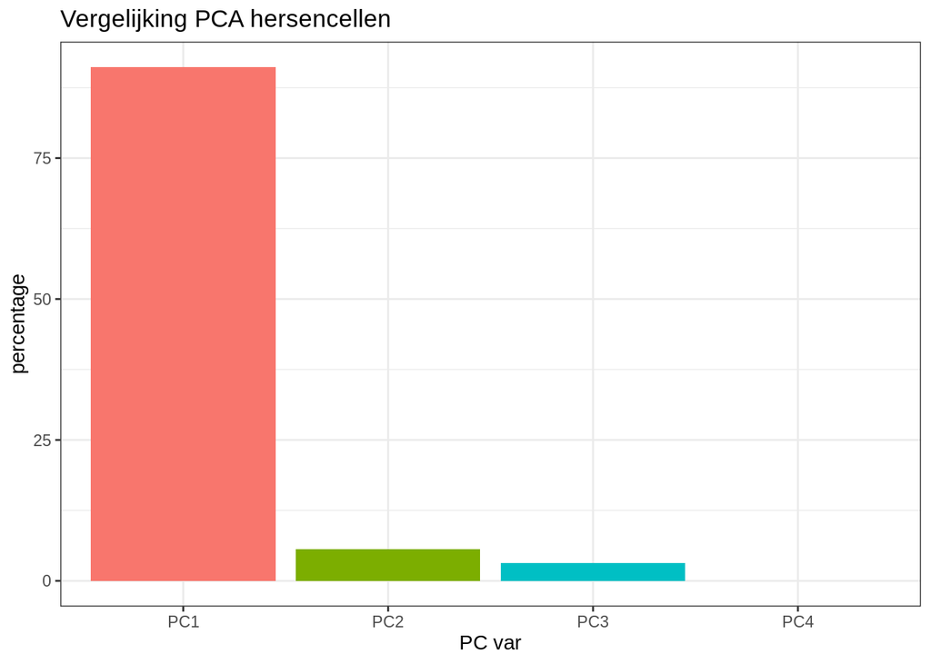

Opdracht 5b

```
##                             PC1      PC2      PC3         PC4
## Standard deviation     38.44093 9.561226 7.233422 1.04819e-13
## Proportion of Variance  0.91135 0.056380 0.032270 0.00000e+00
## Cumulative Proportion   0.91135 0.967730 1.000000 1.00000e+00
```

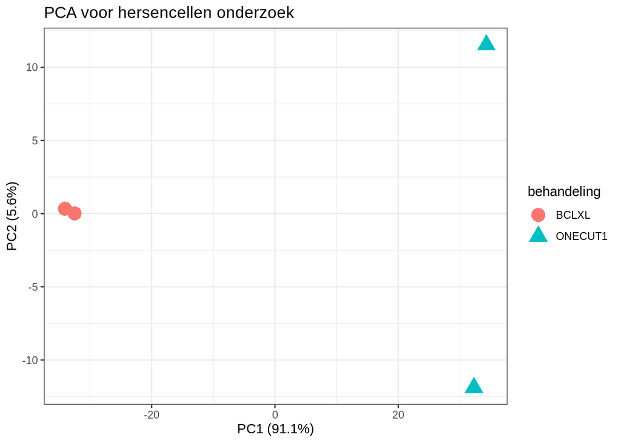

PC1 vangt veruit de meeste variatie van de analyses. PC2 en PC3 vangen nog wat variatie, waarna PC4 zo goed als geen variatie meer vangt. De variatie van ONECUT1 is groot op PC2.

Opdracht 6a

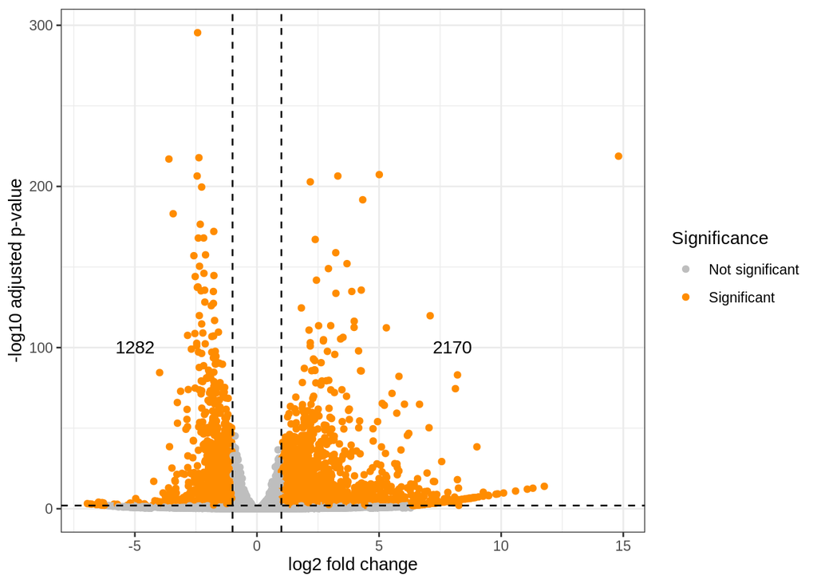

Opdracht 6b

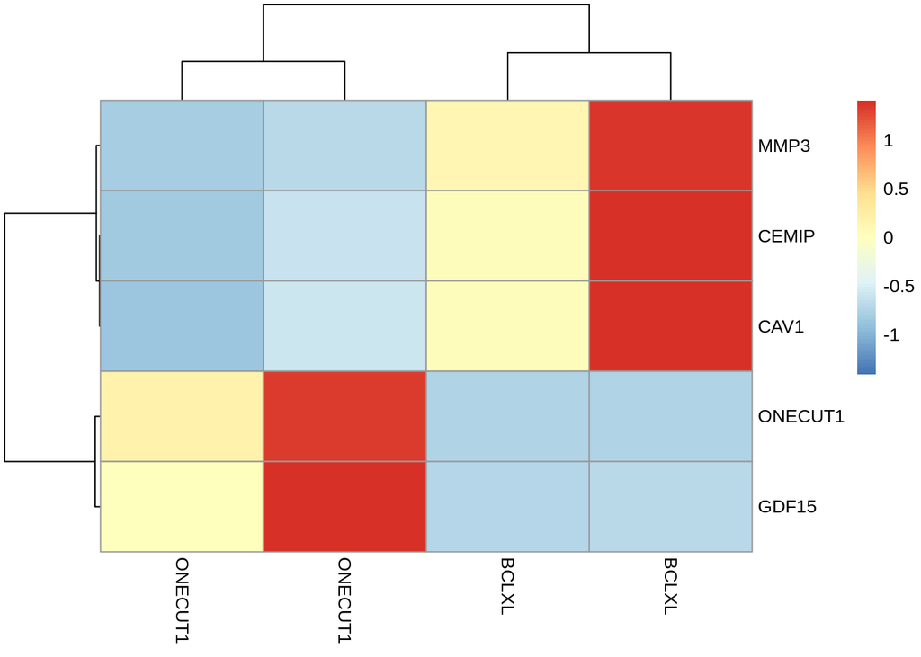

Opdracht 7

```
## $`GO:0036003`
## [1] "ATF4"   "MUC1"   "NFE2L2" "MAPK7"  "TP53"   "KLF2"   "GCN1"
```

Opdracht 8

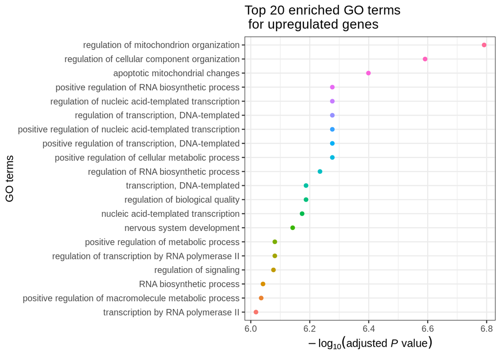

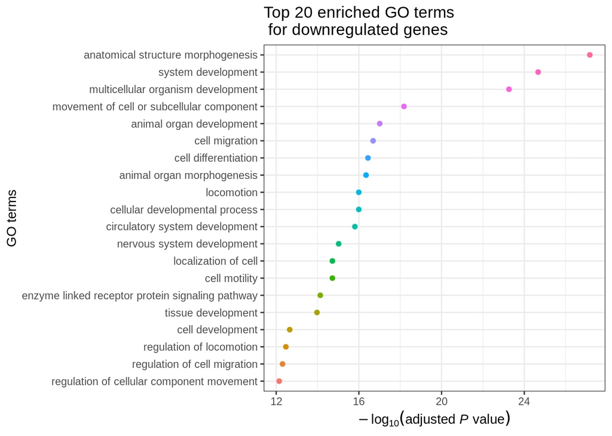